# Project5

# Outlier/Anomaly Detection

Throughout our data cleaning process, we have identified numerous variables with outliers. Below, we will decide what to do with these variables. In deciding what to do, we must ask ourselves: Are these outliers realistic in context of the real world?

```r
#DEC
df$fico_score <- (df$fico_range_low + df$fico_range_high) / 2
df <- df %>% select(-fico_range_low, -fico_range_high)

#cap <- quantile(df$annual_inc, 0.99)
#df$annual_inc[df$annual_inc > cap] <- cap


# Median imputation on the mort_acc variable

df$mort_acc[is.na(df$mort_acc)] <- 1
#df$mort_acc[is.na(df$mort_acc)] <- median(df$mort_acc, na.rm = TRUE)
sum(is.na(df$mort_acc))
```

```
## [1] 0
```

```r
#Median imputation to the pub_rec_bankrupcies variable
df$pub_rec_bankruptcies[is.na(df$pub_rec_bankruptcies)] <- 0
sum(is.na(df$pub_rec_bankruptcies))
```

```
## [1] 0
```

Here, we are making the strategy of using median imputation in revol_util for making the na’s are effective in prediction. Because we need all the observations in predictions of loan_default.

```r
# Removing rows where revol_util is NA
#df <- df[!is.na(df$revol_util), ]
df$revol_util[is.na(df$revol_util)] <- train_median
#nrow(df)
```

```r
# Capping the revol_util variable
Q1 <- quantile(df$revol_util, 0.25, na.rm = TRUE)
Q3 <- quantile(df$revol_util, 0.75, na.rm = TRUE)
IQR <- Q3 - Q1
upper_bound <- Q3 + 1.5 * IQR
df$revol_util[df$revol_util > upper_bound] <- upper_bound
summary(df$revol_util)
```

```
##    Min. 1st Qu.  Median    Mean 3rd Qu.    Max.
##    0.00   36.10   55.00   53.93   73.00  128.35
```

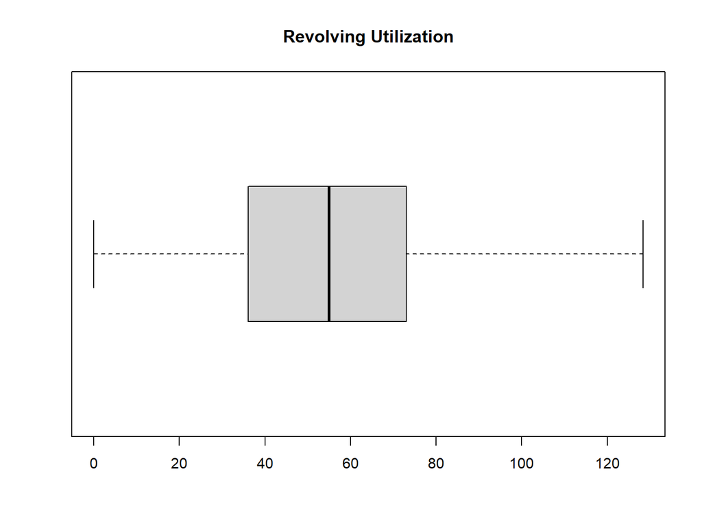

```r
boxplot(df$revol_util, main = "Revolving Utilization", horizontal = TRUE)
```

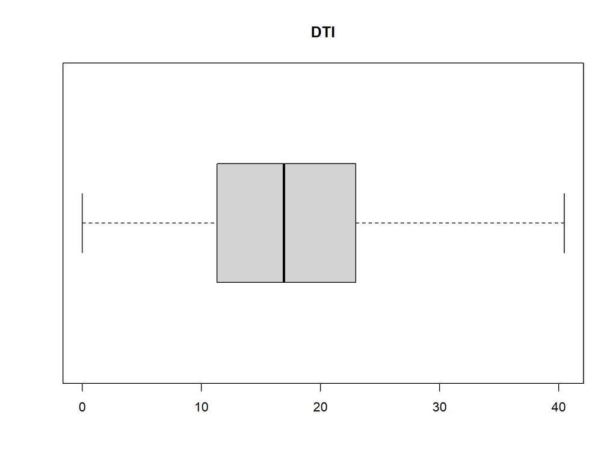

```r
# Capping the dti outlier
Q1 <- quantile(df$dti, 0.25, na.rm = TRUE)
Q3 <- quantile(df$dti, 0.75, na.rm = TRUE)
IQR <- Q3 - Q1

upper_bound <- Q3 + 1.5 * IQR
df$dti[df$dti > upper_bound] <- upper_bound
boxplot(df$dti, main = "DTI", horizontal = TRUE)
```

```r
#Removing the "other" and "none" values
#df <- df[!df$home_ownership %in% c("OTHER", "NONE"), ]
df$home_ownership[df$home_ownership %in% c("OTHER","NONE")] <- "RENT"
df$home_ownership <- droplevels(df$home_ownership)
table(df$home_ownership)
```

```
##
##      ANY MORTGAGE      OWN     RENT
##        1    39751     7619    31872
```

```r
#Reduce dimensions in the purpose variable
df$purpose <- fct_other(df$purpose, keep = c("debt_consolidation", "credit_card", "home_improvement"), other_level = "other")
table(df$purpose)
```

```
##
##        credit_card debt_consolidation   home_improvement              other
##              16618              46765               4848              11012
```

```r
# Reducing dimensions on emp_length
df <- df %>%
  mutate(emp_length = case_when(
    emp_length %in% c("< 1 year", "1 year", "2 years", "3 years") ~ "0-3 years",
    emp_length %in% c("4 years", "5 years", "6 years") ~ "4-6 years",
    emp_length %in% c("7 years", "8 years", "9 years") ~ "7-9 years",
    emp_length == "10+ years" ~ "10+ years",
    TRUE ~ "Unknown"
  ))
df$emp_length <- factor(df$emp_length,
                                levels = c("0-3 years", "4-6 years", "7-9 years", "10+ years","Unknown"),
                                ordered = TRUE)
#df <- df %>%
#  filter(!is.na(emp_length) & emp_length != "Unknown")
```